# **Econometrics**

Difference in Differences with Multiple Periods

Brantly Callaway and Pedro H.C. Sant’Anna

2020/12/11 (updated: 2021-12-01)

### Why `did`?

- The `did` package allows for multiple periods and variation in treatment timing
- The `did` package allows the parallel trends assumption to hold conditional on covariates
- Treatment effect estimates coming from the `did` package do not suffer from any of the drawbacks associated with two-way fixed effects regressions or event study regressions when there are multiple periods / variation in treatment timing
- The `did` package can deliver disaggregated group-time average treatment effects as well as event-study type estimates (treatment effects parameters corresponding to different lengths of exposure to the treatment) and overall treatment effect estimates.

### An application

Now we will walk you through an example on the effect of the minimum wage on youth employment, inspired by [Callaway and Sant’Anna (2020)](https://arxiv.org/abs/1803.09015). Please note that this is just an example of how to use the `did` package in a real-world setup. To really evaluate the effect of the minimum wage on teen employment, one would need to be more careful along a number of dimensions. Thus, results displayed here should be interpreted as illustrative only.

### Data

We use a subset of data that comes from Callaway and Sant’Anna (2020). This is a dataset that contains county-level teen employment rates from 2003-2007. The data can be loaded by

```r
library(did)
data(mpdta)
#View(mpdta)
```

Generate summary statistics

```r
library(stargazer)
stargazer(as.data.frame(mpdta), type = "text")
```

```
##
## ======================================================================
## Statistic     N      Mean     St. Dev.   Min  Pctl(25) Pctl(75)  Max
## ----------------------------------------------------------------------
## year        2,500 2,005.000    1.414    2,003  2,004    2,006   2,007
## countyreal  2,500 32,211.040 13,736.020 8,001 19,112.5 46,110.5 55,137
## lpop        2,500   3.313      1.281    0.066  2.398    4.098   7.705
## lemp        2,500   5.773      1.509    1.099  4.868    6.684   10.443
## first.treat 2,500  766.474    975.095     0      0      2,007   2,007
## treat       2,500   0.382      0.486      0      0        1       1
## ----------------------------------------------------------------------
```

It is a balanced panel with 2500 observations. And the dataset looks like

```r
head(mpdta)
```

```
##     year countyreal     lpop     lemp first.treat treat
## 866 2003       8001 5.896761 8.461469        2007     1
## 841 2004       8001 5.896761 8.336870        2007     1
## 842 2005       8001 5.896761 8.340217        2007     1
## 819 2006       8001 5.896761 8.378161        2007     1
## 827 2007       8001 5.896761 8.487352        2007     1
## 937 2003       8019 2.232377 4.997212        2007     1
```

In particular applications, the dataset should look like this with the key parts being:

- The dataset should be in long format – each row corresponds to a particular unit at a particular point in time.
- There needs to be an id variable (`countyreal` in this data example). The name of this variable is passed to methods in the `did` package by setting, for example, `idname = "countyreal"`
- There needs to be a time variable. In this data example, it is the variable `year`. The name of this variable is passed to methods in the did package by setting, for example, `tname = "year"`
- There needs to be a outcome variable. In this example, the outcome is `lemp`. The name of this variable is passed to methods in the did package by setting, for example, `yname = "lemp"`
- There needs to be a group variable. In this example, it is the variable `first.treat`. This is the time period when an individual first becomes treated. For individuals that are never treated, this variable should be set equal to 0. The name of this variable is passed to methods in the `did` package by setting, for example, `gname = "first.treat"`
- The `did` package allows for incorporating covariates so that the parallel trends assumption holds only after conditioning on these covariates. In this data example, `lpop` is the log of county population. The `did` package requires that covariates be time-invariant. For time varying covariates like county population, the `did` package sets the value of the covariate to be equal to the value of the covariate in the first time period. Covariates are passed as a formula to the `did` package by setting, for example, `xformla = ~lpop`. For estimators under unconditional parallel trends, the `xformla` argument can be left blank or can be set as `xformla = ~1` to only include a constant.

### Estimate group-time average treatment effects

We’ll consider two cases. For the first case, we will not condition on any covariates. For the second, we will condition on the log of county population (in a “real” application, one might want to condition on more covariates).

We first estimate group-time average treatment effects without covariates.

```r
# estimate group-time average treatment effects without covariates
mw.attgt <- att_gt(yname = "lemp",
                   gname = "first.treat",
                   idname = "countyreal",
                   tname = "year",
                   xformla = ~1,
                   data = mpdta,
                   )

# summarize the results
summary(mw.attgt)
```

```
##
## Call:
## att_gt(yname = "lemp", tname = "year", idname = "countyreal",
##     gname = "first.treat", xformla = ~1, data = mpdta)
##
## Reference: Callaway, Brantly and Pedro H.C. Sant'Anna.  "Difference-in-Differences with Multiple Time Periods." Forthcoming at the Journal of Econometrics <https://arxiv.org/abs/1803.09015>, 2020.
##
## Group-Time Average Treatment Effects:
##  Group Time ATT(g,t) Std. Error [95% Simult.  Conf. Band]
##   2004 2004  -0.0105     0.0253       -0.0802      0.0592
##   2004 2005  -0.0704     0.0345       -0.1654      0.0246
##   2004 2006  -0.1373     0.0403       -0.2485     -0.0260 *
##   2004 2007  -0.1008     0.0367       -0.2020      0.0004
##   2006 2004   0.0065     0.0238       -0.0590      0.0721
##   2006 2005  -0.0028     0.0191       -0.0554      0.0499
##   2006 2006  -0.0046     0.0181       -0.0544      0.0452
##   2006 2007  -0.0412     0.0206       -0.0982      0.0157
##   2007 2004   0.0305     0.0149       -0.0105      0.0715
##   2007 2005  -0.0027     0.0165       -0.0483      0.0429
##   2007 2006  -0.0311     0.0186       -0.0823      0.0201
##   2007 2007  -0.0261     0.0162       -0.0708      0.0187
## ---
## Signif. codes: `*' confidence band does not cover 0
##
## P-value for pre-test of parallel trends assumption:  0.16812
## Control Group:  Never Treated,  Anticipation Periods:  0
## Estimation Method:  Doubly Robust
```

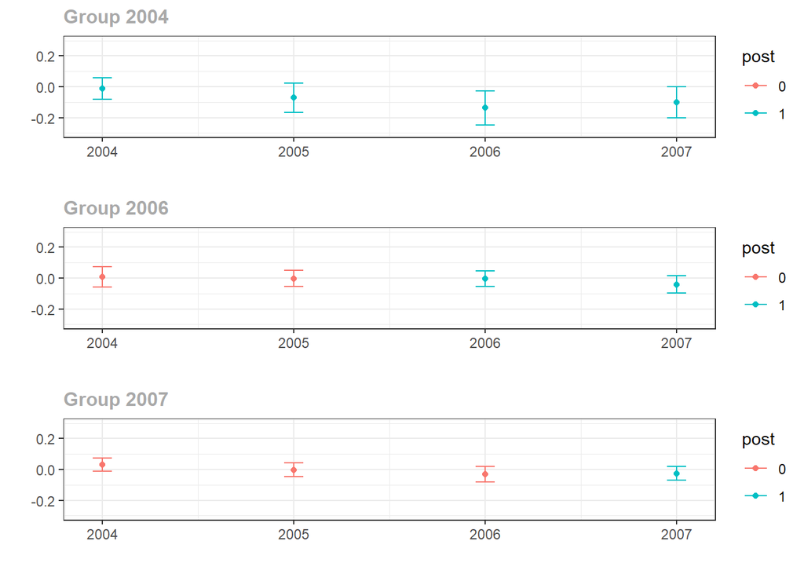

```r
# plot the results
# set ylim so that all plots have the same scale along y-axis
ggdid(mw.attgt, ylim = c(-.3,.3))
```

```r
# aggregate the group-time average treatment effects
mw.dyn <- aggte(mw.attgt, type = "dynamic")
summary(mw.dyn)
```

```
##
## Call:
## aggte(MP = mw.attgt, type = "dynamic")
##
## Reference: Callaway, Brantly and Pedro H.C. Sant'Anna.  "Difference-in-Differences with Multiple Time Periods." Forthcoming at the Journal of Econometrics <https://arxiv.org/abs/1803.09015>, 2020.
##
##
## Overall ATT:
##      ATT Std. Error     [95%  Conf. Int.]
##  -0.0772     0.0213   -0.1191     -0.0354 *
##
##
## Dynamic Effects:
##  event time     ATT Std. Error [95% Simult.  Conf. Band]
##          -3  0.0305     0.0164       -0.0115      0.0725
##          -2 -0.0006     0.0130       -0.0340      0.0329
##          -1 -0.0245     0.0134       -0.0590      0.0101
##           0 -0.0199     0.0114       -0.0493      0.0095
##           1 -0.0510     0.0180       -0.0971     -0.0048 *
##           2 -0.1373     0.0394       -0.2383     -0.0362 *
##           3 -0.1008     0.0364       -0.1943     -0.0074 *
## ---
## Signif. codes: `*' confidence band does not cover 0
##
## Control Group:  Never Treated,  Anticipation Periods:  0
## Estimation Method:  Doubly Robust
```

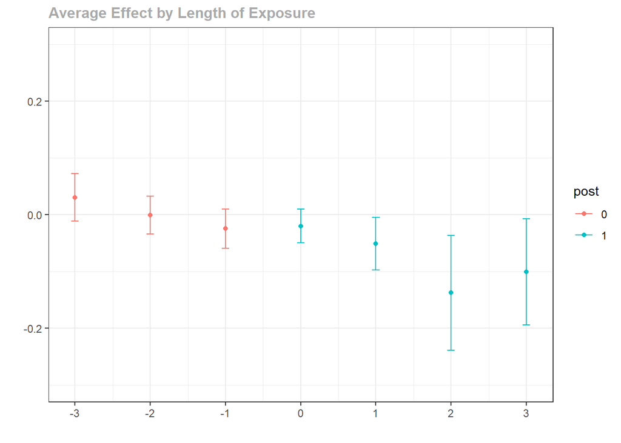

```r
ggdid(mw.dyn, ylim = c(-.3,.3))
```

These continue to be simultaneous confidence bands for dynamic effects. The results are broadly similar to the ones from the group-time average treatment effects: one fails to reject parallel trends in pre-treatment periods and it looks like somewhat negative effects of the minimum wage on youth employment.

One potential issue with these dynamic effect estimators is that the composition of the groups changes with different lengths of exposure in the event study plots.When computing the event-study plot, we would aggregate the effects for all three groups. If the effects of the minimum wage are systematically different across groups (here, there is not much evidence of this as the effect for all groups seems to be close to 0 on impact and perhaps becoming more negative over time), then this can lead to confounding dynamics and selective treatment timing among different groups.

One way to combat this is to balance the sample by (i) only including groups that are exposed to the treatment for at least a certain number of time periods and (ii) only look at dynamic effects in those time periods.

In the `did` package, one can do this by specifying the `balance_e` option. Here, we set `balance_e = 1` – what this does is to only consider groups of states that are treated in 2004 and 2006 (so we can compute event-study-type parameters for them), drops the group treated in 2007 (as we can not compute the event-study-type parameter for this group)), and then only looks at instantaneous average effects and the average effect one period after states raised the minimum wage.

```r
# aggregate the group-time average treatment effects
mw.dyn.balance <- aggte(mw.attgt, type = "dynamic", balance_e=1)
summary(mw.dyn.balance)
```

```
##
## Call:
## aggte(MP = mw.attgt, type = "dynamic", balance_e = 1)
##
## Reference: Callaway, Brantly and Pedro H.C. Sant'Anna.  "Difference-in-Differences with Multiple Time Periods." Forthcoming at the Journal of Econometrics <https://arxiv.org/abs/1803.09015>, 2020.
##
##
## Overall ATT:
##      ATT Std. Error     [95%  Conf. Int.]
##  -0.0288     0.0134   -0.0549     -0.0026 *
##
##
## Dynamic Effects:
##  event time     ATT Std. Error [95% Simult.  Conf. Band]
##          -2  0.0065     0.0240       -0.0503      0.0633
##          -1 -0.0028     0.0196       -0.0492      0.0437
##           0 -0.0066     0.0149       -0.0420      0.0288
##           1 -0.0510     0.0170       -0.0912     -0.0108 *
## ---
## Signif. codes: `*' confidence band does not cover 0
##
## Control Group:  Never Treated,  Anticipation Periods:  0
## Estimation Method:  Doubly Robust
```

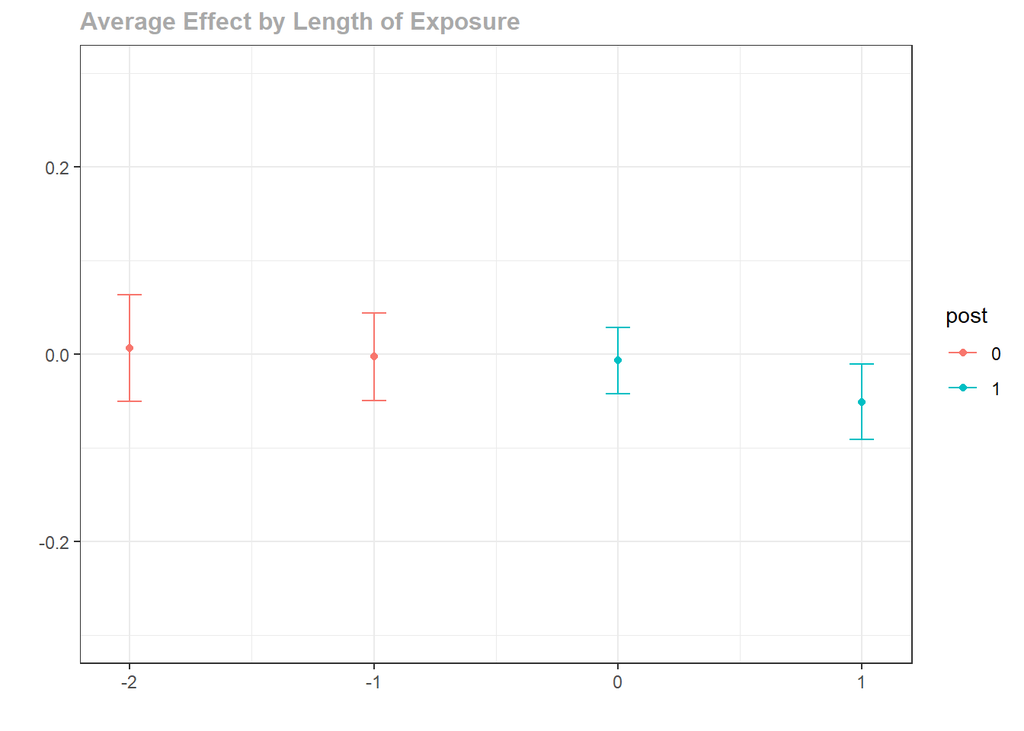

```r
ggdid(mw.dyn.balance, ylim = c(-.3,.3))
```

Finally, we can run all the same results including a covariate. In this application the results turn out to be nearly identical, and here we provide just the code for estimating the group-time average treatment effects while including covariates. The other steps are otherwise the same.

```r
mw.attgt.X <- att_gt(yname = "lemp",
                   gname = "first.treat",
                   idname = "countyreal",
                   tname = "year",
                   xformla = ~lpop,
                   data = mpdta,
                   )
```

## Discussion

The `did` package is only built to handle staggered treatment adoption designs. This means that once an individual becomes treated, they remain treated in all subsequent periods.